# Assignment 4.5

**Ian Hinds**

The final assignment/project is to create a Jupyter Notebook that explains coastal processes and potential sources of pollution to a coastal environment. This could be a beach that you grew up going to, an estuary that is formed at the mouth of the watershed that you live in, or somewhere that you've always wanted to visit. Imagine the notebook to be the draft material for creating an interpretive sign, or background research for an Environmental Impact Statement.

The content of the notebook should reflect a synthesis of the course material. Note that the two main goals in this course were to:

- Understand major factors impacting movement of water in coastal systems
- Acquire basic knowledge about pollutants and their impacts in coastal ecosystems

**Virginia Beach and Local Geography**

[figure not shown]

**Pollutant Summary Table**

1. A summary table with the following columns and rows:

| Pollutant | Main source | Main pathway | Ecosystem risk |
| --- | --- | --- | --- |
| Pathogens | Human Waste | Fecal/Urine Contamination | Low |
| Nutrients | Urbanization | Runoff | Moderate |
| Oil | N/A | N/A | Very Low |
| Plastics | Human Waste | Waste Disposal | Moderate |
| Chemicals | Industrial Waste | Runoff | Low |

**Pollutants Summary**

1. Descriptions of, and justifcations for, your summary points.

Virginia Beach is a relatively clean recreational oceanfront that is impacted mostly by human and industrial waste sources. Bacterial Pathogens are commonly tested in this area, and infrequently lead to beach closures. The main source of bacterial pollution during the summer season, would be from human waste more than animal or agricultural, as it is a heavily visited location. Additional pathogen pollution is from sewage lines feeding into the ocean. Nutrient pollution is most impacted by increasing urbanization in the surrounding area as tourism and military developments are consistently present. There is little to no oil pollution at Virginia Beach due to an absence of offshore drilling sites, however, spills in the gulf, or the south section of the East Coast could potentially impact the area due to ocean current patterns.

Plastic and Chemical pollutants are sourced from inproper human waste disposal and industrial waste. Although virginia beach is located on the southern corner of the Chesapeake Bay, growing agricultural and industrial sites are affecting the regional ecosystem through runoff and atmospheric emissions. Plastic pollution is also sourced from oceanic circulation, as the Gulf Stream transports a large volume of water poleward along the eastern United States.

**Ocean Water Transport Factors**

1. An overview of the major factors that contribute to the transport time of water through your ecosystem.

Coastal Erosion commonly affects the volume of sand at Virginia Beach. During Hurricanes or Nor'Easter storms, heavy winds and agressive tides transport large amounts of sand offshore, and erode the beach. In normal conditions, there are usually no natural disturbances to beach composition. Surface Waves generated at Virginia Beach are relient on global and local winds. The local tides have a semidirunal cycle with 2 high and low tides per day. Tidal patterns influence much of the ongoing sediment transport and local water weight. Wind direction varies throughout the year, and is primarily from the south during summer and from the north during fall and winter. Wind speeds peak in the fall and winter months as storms from the south and north develop annually.

**Virginia Beach Average Wind Speed, Monhtly (NOAA Station: CHYV2, 2007-2012)**

1. A plot showing data of one of the elements in element 4.

The plot below demonstrates low surface winds in the summer months, and higher winds in the winter and fall storm months.

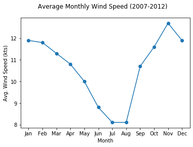

```python
import matplotlib.pyplot as plt    # basic plotting functions
from mpl_toolkits.axes_grid1.inset_locator import inset_axes
import pandas as pd
import numpy as np
from pandas.plotting import register_matplotlib_converters
register_matplotlib_converters()

VAB_df = pd.read_csv('VAB.csv', sep=',', header=[0], na_values='NaN')

fig = plt.figure()
plt.scatter(VAB_df.month, VAB_df.avg_w_spd)
plt.plot(VAB_df.month, VAB_df.avg_w_spd)
fig.suptitle('Average Monthly Wind Speed (2007-2012)')
plt.xlabel('Month')
plt.ylabel('Avg. Wind Speed (kts)')
plt.show()
```

**Sources:**

*Station CHYV2 - 8638999 - Cape Henry, VA*

*Virginia Beach Weather: https://weatherspark.com*

*Virginia Beach Pollution and Erosion Info: https://www.vbgov.com*

*Additional Data and Information: https://www.ndbc.noaa.gov*

*Mapping Software: https://sartopo.com/m/GH3G*